# 梯度下降

之前我们提到的多重共线性的问题，其中一个解决办法就是改变原来的模型，将模型的先觉条件放松后，才有了其他的解决办法。但是对一些复杂的模型来说，放宽条件更改模型的做法很复杂。所以就有了梯度下降的方法。

该方法可以说是一种贪心算法。是一个最优化算法，通常也称 最速下降法，常用于机器学习和人工智能中递归性逼近最小偏差模型，梯度下降的方向就是用负梯度方向为搜索方向，沿着梯度下降的方向求解极小值。在训练过程中，每次的正向传播都会得到输出值和真实值的损失值，这个损失值越小，代表模型越好，于是梯度下降的算法就用在这里，帮助寻找最小的那个损失值。

## 1 坐标下降

我们使用的lasso就是用的坐标的方法。过程还是比较复杂的。坐标下降也属于贪⼼算法，⾸先预设每个⾃变量系数均为0，然后执⾏循环，每次循环过程中都对其中某个变量进⾏相同步⻓的增加或者减少，同时对⽐改变之后⽬标函数的下降速度，并选取⽬标函数下降速度最快的更改⽅案，然后对系数进⾏永久性质的更改，接着执⾏下⼀次迭代，直⾄抵达收敛条件为⽌，其基本执⾏过程如下伪代码所示。

向前回归法伪代码如下:

> 若有必要，首先将数据进行归一化处理

> 设置迭代收敛条件，然后进⾏迭代：

> 设置当前最⼩误差lowestError为正⽆穷

> 假设数据集有3个特征，也就是3列。所有回归的参数就可以为w = [w1, w2, w3]。这是我们的初始参数

> 迭代n次，比如说迭代10000次，也就是10000个循环，每个循环里做以下的操作

> > 对于每个特征都做以下的操作：

> > > 按步⻓增⼤或缩⼩

> > > 特征w += 步长，或者特征w -= 步长， 算一下SSE， 2个取SSE最小的那个， 记为更新这个特征w后的新SSE

> > > (new_SSE, new_wi, old_wi)

> > 这个时候每一个列都有个新SSE，[(new_SSE1, new_w1, old_w1), (new_SSE2, new_w2, old_w2), (new_SSE3, new_3, old_w3)]

> > 取最小的new_SSE, 比如说现在new_SSE2最小，说明我们在改变w2的值整体SSE下降效果最好

> > 更新我们的w, 从[w1, w2. w3] 变成 [w1, new_w2, w3]

> > 新的w带入下一次循环

```python
import numpy as np
import pandas as pd
from matplotlib import pyplot as plt

aba = pd.read_csv('abalone.txt', header = None, sep = '\t')
x = aba.iloc[:,:-1]
y = aba.iloc[:,-1]

def regularize(xMat):
    inMat = xMat.copy()
    inMeans = np.mean(inMat,axis=0)
    inStd = np.std(inMat,axis=0)
    inMat = (inMat - inMeans) / inStd
    return inMat

X = np.mat(regularize(x))
Y = np.mat(regularize(y)).reshape(-1,1)

X = np.column_stack((np.ones((X.shape[0], 1)), X))
#X_norm = np.linalg.norm(X, axis = 0)
#X = X/X_norm
```

首先我们先选出我们的最开始的theta，可以让最开始的theta全部都等于0.

接着写一个算整体回归SSE的函数，方面每次迭代中算SSE的部分

```python
def Calculating_SSE(X, Y, w):
    return np.power(Y - X * w, 2).sum()

#Calculating_SSE(X, Y, initial_theta)
```

现在我们开始写我们的循环

```python
num_inter = 5000
initial_theta = np.zeros((X.shape[1], 1))
theta = initial_theta
alpha = 0.001
print(theta.T)

for _ in range(num_inter):
    tmp_SSE_l = []
    for j in range(theta.shape[0]):
        w_values = theta[j][0]
        w_p, w_m = w_values + alpha, w_values - alpha
        tmp_theta = theta.copy()
        tmp_theta[j] = w_p
        SSE_p = Calculating_SSE(X, Y, tmp_theta)
        tmp_theta[j] = w_m
        SSE_m = Calculating_SSE(X, Y, tmp_theta)
        binary_tmp_SSE = [[SSE_p, w_p],[SSE_m, w_m]]
        binary_tmp_SSE.sort()
        tmp_SSE_l.append(binary_tmp_SSE[0] + [j])
    tmp_SSE_l.sort()
    theta_new, theta_index = tmp_SSE_l[0][-2:]
    theta[theta_index] = theta_new

theta.T
```

```
[[0. 0. 0. 0. 0. 0. 0. 0. 0.]]
```

```
array([[ 0.   ,  0.016, -0.052,  0.406,  0.154,  1.391, -1.39 , -0.328,
         0.377]])
```

```python
l = [[3,5], [2,4]]
l.sort()
l
```

```
[[2, 4], [3, 5]]
```

```python
np.around(((X.T*X).I * X.T * Y).T,2)
```

```
array([[ 0.  ,  0.02, -0.06,  0.41,  0.15,  1.41, -1.4 , -0.33,  0.37]])
```

当前，我们完成了核心的代码的编写。将它写成一个函数。

```python
def Calculating_SSE(X, Y, w):
    return np.power(Y - X * w, 2).sum()

def step_wise(X, Y, num_inter, alpha, initial_value = 0, same_value = True, initial_theta = None):
    if same_value:
        initial_theta = np.ones((X.shape[1], 1)) * initial_value
    else:
        initial_theta = list(initial_theta)
        initial_theta = np.mat(initial_theta).T

    theta = initial_theta
    l_complex = []

    for _ in range(num_inter):
        tmp_SSE_l = []
        for j in range(theta.shape[0]):
            w_values = theta[j][0]
            w_p, w_m = w_values + alpha, w_values - alpha
            tmp_theta = theta.copy()
            tmp_theta[j] = w_p
            SSE_p = Calculating_SSE(X, Y, tmp_theta)
            tmp_theta[j] = w_m
            SSE_m = Calculating_SSE(X, Y, tmp_theta)
            binary_tmp_SSE = [[SSE_p, w_p],[SSE_m, w_m]]
            binary_tmp_SSE.sort()
            tmp_SSE_l.append(binary_tmp_SSE[0] + [j])
        tmp_SSE_l.sort()
        theta_new, theta_index = tmp_SSE_l[0][-2:]
        theta[theta_index] = theta_new
        if _ in [10,100,1000, 5000]:
            print(theta.T)
        l_complex.append(np.ravel(theta.copy()))
    return l_complex
```

```python
l_complex = step_wise(X, Y, 6000, alpha = 0.001)
```

```
[[0.    0.    0.    0.    0.    0.    0.    0.    0.011]]
[[0.    0.    0.    0.    0.    0.    0.    0.    0.101]]
[[ 0.     0.     0.     0.055  0.124  0.    -0.211  0.     0.611]]
[[ 0.     0.017 -0.052  0.406  0.154  1.391 -1.39  -0.328  0.377]]
```

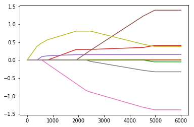

```python
plt.plot(l_complex)
```

现在用我们的线性回归中的数据做测试

```python
from sklearn.datasets import fetch_california_housing as fch

housevalue = fch()
data = pd.DataFrame(housevalue.data, columns = housevalue.feature_names)
data['Price'] = housevalue.target
test_data = data.sample(frac = 0.3, replace = False)
train_index = set(data.index) - set(test_data.index)
train_data = data.loc[train_index]
```

```python
X = np.mat(train_data.iloc[:, :-1].values)
Y = np.mat(train_data.iloc[:, -1].values).T
X = np.column_stack((np.mat(np.ones(X.shape[0])).T, X))
```

```python
l_complex = step_wise(X, Y, num_inter = 8000, alpha = 0.01, same_value = False,
                      initial_theta = [-36 ,   0.4,   0. ,  -0.1,   0,  -0. ,  -0. ,  -0.4,  -0.4]
                     )
```

```
[[-3.601e+01  3.700e-01  0.000e+00 -7.000e-02  0.000e+00 -0.000e+00
  -1.000e-02 -4.000e-01 -4.300e-01]]
[[-3.656e+01  3.700e-01  0.000e+00 -4.000e-02  2.600e-01 -0.000e+00
  -1.000e-02 -4.000e-01 -4.300e-01]]
[[-3.664e+01  3.800e-01  0.000e+00 -4.000e-02  2.900e-01 -0.000e+00
  -1.000e-02 -4.000e-01 -4.300e-01]]
[[-3.664e+01  3.800e-01  0.000e+00 -4.000e-02  2.900e-01 -0.000e+00
  -1.000e-02 -4.000e-01 -4.300e-01]]
```

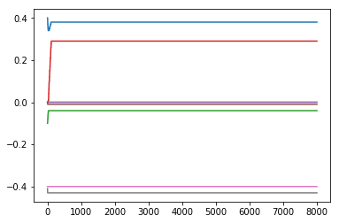

```python
plt.plot([i[1:] for i in l_complex])
```

```python
np.around(((X.T*X).I * X.T * Y).T, 1)
```

```
array([[-37.6,   0.4,   0. ,  -0.1,   0.6,  -0. ,  -0. ,  -0.4,  -0.4]])
```

```python
np.around(l_complex[-1], 1)
```

```
array([-36.6,   0.4,   0. ,  -0. ,   0.3,  -0. ,  -0. ,  -0.4,  -0.4])
```

## 2 梯度下降详解

引用机器学习使用指南里的一句话来解释梯度下降。

> ‘假设浓雾下，你迷失在了大山中，你只能感受到自己脚下的坡度。为了最快到达山底，一个最好的方法就是沿着坡度最陡的地方下山。这其实就是梯度下降所做的：它计算误差函数关于参数向量$\theta$的局部梯度，同时它沿着梯度下降的方向进行下一次迭代。当梯度值为零的时候，就达到了误差函数最小值 。’

算法的过程，在一开始，要选一个初始的$\theta$，然后定义一个步长，来一点一点的改变我们的$\theta$值，直到SSE达到一个最小值。如下图。

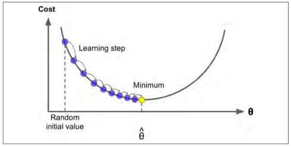

从上面的图中我们可以看到，Cost是Y轴，$\theta$x轴，简单的来说Cost是一个$\theta$的函数。这里我们可以看出我们选了一个随机的起始点，然后根据步长。一步一步的在降低cost的值，一直到最底端。

步数的大小也是我们自己定义的。步数可大可小。

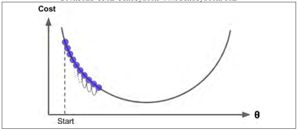

上图中，可以看出我们的步数很小的时候，则达到最低端的时间会更加的长，但是由于步长小，所以最后的结果精确度很高，并且非常接近global minimal。

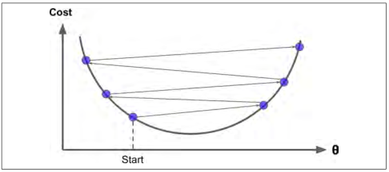

那上面的情况是基于cost函数是一个convex函数，也就是说它只有一个全局最优点，也就是global minimal。比如说，我们的最小2乘来求回归问题的cost函数(多维)就是一个典型的convex函数，也就是只有一个最优点。后面我们的做梯度下降的练习也还是围绕着回归来做。

但是真实的生活中，我们会涉及到其他很多的损失函数。这些损失函数大多数都是不规则的函数，有多个局部最优(local minimal)和一个全局最优(gloabl minial)。比如下面的图。

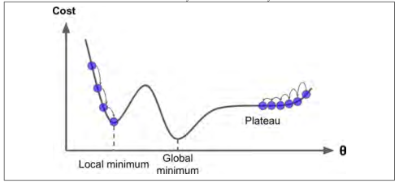

那在这个损失函数中，我们可以看到，如果选左边的点为起始点，最后很可能就陷入一个local minimal中出不来了。假如从右边的点作为起始点。则我们可能会达到全局最优点。

在使用梯度下降的时候，需要做的是要抱他所有的特征有着相近的尺度范围。也就是说，如果有的特征是以100为单位的，有的特征是以1为单位的，如果不做归一化处理的话，并且选取步长为0.1的话，以100为单位的特征需要很长时间才能达到真实的点。这样会拖累整个迭代用的时间。如果做了归一化处理的话，所有的特征值都可能是0到1的范围内，用0.1作为步长的话，很是合理。

### 2.1 梯度下降的详细算法

1. 先决条件： 确认优化模型的假设函数和损失函数。比如对多元的线性回归来说，我们的损失函数就是最小二乘法的那个函数。

$$MSE = \frac{1}{n}(Y - X\theta)^T(Y - X\theta)$$

1. 选取一个初始化的参数值，比如说$\theta = (0,0,...,0)$。然后选取一个步长$\lambda = 0.1$
2. 根据损失函数算出偏微分$\nabla$

$$ \nabla MSE(\theta) = \left[ \begin{matrix} \frac{dMSE(\theta)}{d \theta_{0}} \\ \frac{dMSE(\theta)}{d \theta_{1}} \\ \vdots \\ \frac{dMSE(\theta)}{d \theta_{p}} \end{matrix} \right] = \frac{2}{n}X^T(X\theta-Y) $$

1. 更新$\theta$直到$\theta$收敛

$$\theta = \theta - \lambda \nabla MSE(\theta) = \theta - \lambda \frac{2}{n}X^T(X\theta-Y)$$

### 2.2 梯度下降算法种类

#### 2.2.1 批量梯度下降法（Batch Gradient Descent）

批量梯度下降法，是梯度下降法最常⽤的形式，具体做法也就是在更新参数时使⽤所有的样本来进⾏更新。也就是说下列的X和Y用的就是整个数据集。

$$\theta = \theta - \lambda \frac{2}{n}X^T(X\theta-Y)$$

#### 2.2.2 随机梯度下降法（Stochastic Gradient Descent）

随机梯度下降法，其实和批量梯度下降法原理类似，区别在与求梯度时没有⽤所有的m个样本的数⽽是仅仅选取⼀个样本j来求梯度。对应的更新公式是：

$$\theta = \theta - \lambda X_{j}^T (X_{j}\theta - y_{i})$$

随机梯度下降和批量梯度下降法是两个极端，⼀个采⽤所有数据来梯度下降，⼀个⽤⼀个样本来梯度下降。⾃然各⾃的优缺点都⾮常突出。对于训练速度来说，随机梯度下降法由于每次仅仅采⽤⼀个样本来迭代，训练速度很快，⽽批量梯度下降法在样本量很⼤的时候，训练速度不能让⼈满意。对于准确度来说，随机梯度下降法⽤于仅仅⽤⼀个样本决定梯度⽅向，导致解很有可能不是最优。对于收敛速度来说，由于随机梯度下降法⼀次迭代⼀个样本，导致迭代⽅向变化很⼤，不能很快的收敛到局部最优解。 但值得⼀提的是，随机梯度下降法在处理⾮凸函数优化的过程当中有⾮常好的表现，由于其下降⽅向具有⼀定随机性，因此能很好的绕开局部最优解，从⽽逼近全局最优解。

那么，有没有⼀个中庸的办法能够结合两种⽅法的优点呢？有，⼩批量梯度下降法。

#### 2.2.3 ⼩批量梯度下降法（Mini-batch Gradient Descent）

⼩批量梯度下降法是批量梯度下降法和随机梯度下降法的折衷，也就是对于n个样本，我们采⽤m个样⼦来迭代。一般m=10即可，或者可以用0.1 * n。所以下面的公式里的每次迭代的时候用的X和Y就不是全部的样本，而是其中一小部分的数据。

X = X.sample(frac = 0.1, replace = False)

Y = Y[X.index]

$$\theta = \theta - \lambda \frac{2}{n}X^T(X\theta-Y)$$

## 3 梯度下降法python实现

```python
aba = pd.read_csv('abalone.txt', header = None, sep = '\t')
x = aba.iloc[:,:-1]
y = aba.iloc[:,-1]

def regularize(xMat):
    inMat = xMat.copy()
    inMeans = np.mean(inMat,axis=0)
    inStd = np.std(inMat,axis=0)
    inMat = (inMat - inMeans) / inStd
    return inMat

X = np.mat(regularize(x))
X = np.column_stack((np.ones((X.shape[0], 1)), X))
Y = np.mat(regularize(y)).reshape(-1,1)
```

### 3.1 Batch GD

```python
def Batch_GD(X, Y, lam = 0.1, n = 5000):
    l_theta = []
    theta = np.mat(np.zeros((X.shape[1], 1)))
    for _ in range(n):
        grad = 2 * lam/X.shape[0] * X.T*(X*theta - Y)
        theta -= grad
        l_theta.append(np.ravel(theta.copy()))
    return l_theta
```

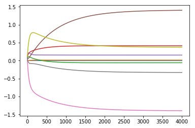

```python
l_theta = Batch_GD(X, Y, n = 4000)
plt.plot(l_theta)
```

```python
np.around(l_theta[-1], 3)
```

```
array([ 0.   ,  0.016, -0.059,  0.413,  0.154,  1.4  , -1.393, -0.33 ,
        0.373])
```

### 3.2 Stocastic_GD

```python
def Stocastic_GD(X, Y, lam = 0.1, n = 5000):
    l_theta = []
    theta = np.mat(np.zeros((X.shape[1], 1)))
    for _ in range(n):
        j = np.random.randint(X.shape[0])
        X_j, Y_j = X[j], Y[j]
        grad = 2 * lam/X.shape[0] * X_j.T * (X_j * theta - Y_j)
        theta -= grad
        l_theta.append(np.ravel(theta.copy()))
    return l_theta
```

```
array([-0.04110973,  0.04581589, -0.04475082,  0.42176051,  0.14707944,
        1.31024009, -1.37007814, -0.33699217,  0.37719947])
```

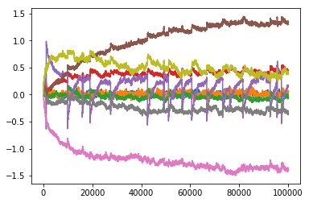

```python
l_theta = Stocastic_GD(X, Y, lam = 10, n = 100000)
plt.plot(l_theta)
l_theta[-1]
```

### 3.3 MiniBatch_GD

```python
def Mini_GD(X, Y, lam = 0.1, n = 5000):
    l_theta = []
    theta = np.mat(np.zeros((X.shape[1], 1)))
    temp_X = pd.DataFrame(X)
    for _ in range(n):
        X_index = temp_X.sample(frac = 0.1, replace = False).index
        X_mini = X[X_index, :]
        Y_mini = Y[X_index]
        grad = 2 * lam/X.shape[0] * X_mini.T * (X_mini * theta - Y_mini)
        theta -= grad
        l_theta.append(np.ravel(theta.copy()))
    return l_theta
```

```
array([ 0.01106774,  0.02582873, -0.06272109,  0.39909387,  0.17171016,
        1.38878737, -1.40444111, -0.33712768,  0.35828778])
```

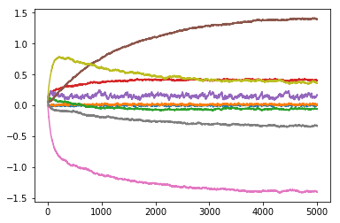

```python
l_theta = Mini_GD(X, Y, lam = 0.6)
plt.plot(l_theta)
l_theta[-1]
```

PRACTISE

将上面所有的3个做个类，梯度下降的种类作为种类传入类中